# Tarea: Base de datos

# Introducción

En este notebook, utilizaremos **SQL en R** para realizar una exploración eficiente de una base de datos. Al integrar consultas SQL con R, aprovechamos la potencia de ambas herramientas: SQL para la gestión y consulta de grandes volúmenes de datos, y R para su análisis y visualización.

A lo largo de este notebook, realizaremos diversas consultas SQL para extraer información clave, filtrar datos, realizar agregaciones y crear subconjuntos de datos que luego serán analizados con R. Este enfoque facilitará el análisis de grandes cantidades de registros de manera más ágil y estructurada.

En primer lugar, imprimimos los nombres de todas las tablas de nuestra base de datos:

```r
print(dbListTables(conn))
```

```
 [1] "Category"             "Customer"
 [3] "CustomerCustomerDemo" "CustomerDemographic"
 [5] "Employee"             "EmployeeTerritory"
 [7] "OrderDetail"          "Orders"
 [9] "Product"              "ProductDetails_V"
[11] "Region"               "Shipper"
[13] "Supplier"             "Territory"
```

También, calculamos el total de ventas donde la venta es igual a:
$$(PrecioUnitario-Descuento)*Cantidad$$

```sql
--Total de ventas por orden realizada
SELECT OrderId,sum((UnitPrice-Discount)*Quantity) as 'Total de ventas'
FROM OrderDetail
GROUP BY OrderId;
```

| OrderId | Total de ventas |
| --- | --- |
| 10248 | 440.00 |
| 10249 | 1863.40 |
| 10250 | 1805.50 |
| 10251 | 669.75 |
| 10252 | 3726.75 |
| 10253 | 1444.80 |
| 10254 | 619.80 |
| 10255 | 2490.50 |
| 10256 | 517.80 |
| 10257 | 1119.90 |

[output cut: 990 more lines]

En la siguiente consulta, mostramos el total de ventas por país de origen del cliente.

```sql
--Venta total por país de origen
SELECT Customer.Country as 'País de origen del cliente',
sum(OrderDetail.VentaTotal) as 'Total de ventas'
FROM Orders
INNER JOIN Customer ON Customer.Id=Orders.CustomerId
---Calculo de la venta total por orden
INNER JOIN (
SELECT OrderId,sum((UnitPrice-Discount)*Quantity) as VentaTotal
FROM OrderDetail
GROUP BY OrderId) OrderDetail ON OrderDetail.OrderId=Orders.Id
--Agrupamos por pais de origen del cliente
GROUP BY Customer.Country
ORDER BY Customer.Country;
```

| País de origen del cliente | Total de ventas |
| --- | --- |
| Argentina | 14803755 |
| Austria | 9951130 |
| Belgium | 9668458 |
| Brazil | 47462658 |
| Canada | 15097189 |
| Denmark | 10607029 |
| Finland | 10359348 |
| France | 54380259 |
| Germany | 55543253 |
| Ireland | 4431249 |

[output cut: 10 more lines]

```sql
-- Descuentos de los productos contenidos en cada categoría
SELECT Product.CategoryId as 'Categoría',
sum(Discount) as 'Total de descuento'
FROM OrderDetail
INNER JOIN Product ON Product.Id=OrderDetail.ProductId
GROUP BY Product.CategoryId;
```

| Categoría | Total de descuento |
| --- | --- |
| 1 | 25.00 |
| 2 | 11.37 |
| 3 | 19.02 |
| 4 | 19.56 |
| 5 | 8.88 |
| 6 | 11.15 |
| 7 | 6.18 |
| 8 | 19.88 |

Por último, se realiza una consulta para conocer la demanda de los productos de los provedores de Españaa través de los meses. De manera que con la siguiente consulta **SQL** obtenemos la cantidad de producto vendido de acuerdo a su fecha de pedido.

```sql
--Obtenemos el año y el mes de cuando se realiza la orden
SELECT strftime("%Y-%m", Orders.OrderDate) as YearMonth,
--Calculamos la cantidad de productos vendidos
sum(OrderDetail.Quantity) as 'Productos Vendidos'
FROM Product
INNER JOIN Supplier ON Supplier.Id=Product.SupplierId
INNER JOIN OrderDetail ON OrderDetail.ProductId=Product.Id
INNER JOIN Orders ON Orders.Id=OrderDetail.OrderId
--Seleccionamos sólo los provedores de españa
WHERE Country='Spain'
--Agrupamos por mes
GROUP BY YearMonth
ORDER BY YearMonth ASC;
```

A continuación, mostramos la información de la consulta de manera gráfica.

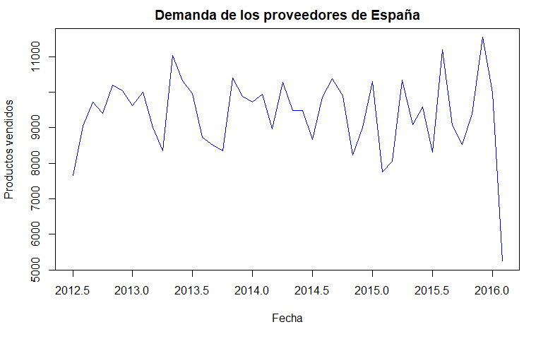

Para finalizar el proceso, es importante realizar la **desconexión de la base de datos** para liberar los recursos utilizados durante la sesión. Esto garantiza que no queden conexiones abiertas que puedan afectar el rendimiento o generar problemas en futuros accesos a la base de datos. Al cerrar correctamente la conexión, aseguramos que los cambios o consultas realizados durante el análisis se almacenen adecuadamente y evitamos posibles bloqueos o errores en el sistema.